# 0_LSR data - infer HOME and WORK location - behavioral pattern

```python
from IPython.display import HTML

HTML('''<script>
code_show=true;
function code_toggle() {
 if (code_show){
 $('div.input').hide();
 } else {
 $('div.input').show();
 }
 code_show = !code_show
}
$( document ).ready(code_toggle);
</script>
<form action="javascript:code_toggle()"><input type="submit" value="Click here to toggle on/off the raw code."></form>''')
```

```python
from platform import python_version
print(python_version())
```

```
3.5.2
```

```python
import os
import pandas as pd
import dask.dataframe as dd
import timeit
import csv
import pickle
from multiprocessing import Pool

import matplotlib.pyplot as plt
%matplotlib inline
plt.style.use('dark_background')

os.chdir('/data/ros/')
```

# Overview

- **Objective:** The objective of the behavioral method is to identify home/workplace from locations of individuals based on the **observed longitudinal presences**.
- **Raw data:** each user has a sequence of coordinates with timestamps across the observational period
  - Each record in the raw data is a "presence", an assumed activity type or trip purpose of a person
- **Unit of interest: person-location**
- **Feature:**
  - Normalized Hourly Presence (NHP) - used as a set of hourly features
    - characterizes the temporal presence patterns of individuals at user location
    - acts as a vector of probability distribution capturing the likelihood that the person will appear in that location for a given time of day
    - is computed as the average number of presences in each hour of a weekday (or a weekend) for a particular user-location
    - is computed per person per hour per location
    - weekdays and weekends are aggregated separately because we expect different pattern of schedules (e.g. people have more spare time during weekend)
    - each person-location is characterized by 48 Normalized Hourly Presence (NHPs)
      - 24 hrs for weekday
      - 24 hrs for weekend
- **Target input:**
  - After preprocessing, the raw data should be transformed into this kind of matrix format:

```
                wdhr0 wdhr1 wdhr2 ... wdh23 wehr0 wehr1 wehr2 ... weh23
        id1loc1
        id1loc2
        id2loc1
        .
        .
        .
        idnlocn
```

# Preprocessing

Preprocess the raw data into a matrix of historical geo-temporal data

```python
files = [file for file in os.listdir() if '_sample100.pkl' in file]

def pickle_load(filename):
    with open(filename,'rb') as file:
        return pickle.load(file)

for ith_file in range(len(files)):
    if ith_file <= 0:
        main_df = pickle_load(files[ith_file])
        print('ith_file, main_df.shape = ',ith_file, main_df.shape, len(list(set(main_df.id))))
    else:
        df = pickle_load(files[ith_file])
        print('ith_file, main_df.shape,df.shape,len_df = ', ith_file, main_df.shape,df.shape, len(list(set(df.id))))
        main_df = pd.concat([main_df,df], axis=0)
```

### Semi-preprocessed data

```python
main_df.columns
```

```
Index(['id', 's_day', 'hour', 'lat', 'long', 'count'], dtype='object')
```

```python
ddf = dd.from_pandas(main_df, npartitions=12)
```

```python
main_df.head(5)
```

|  | id | s_day | hour | lat | long | count | day | latlong | hr |
| --- | --- | --- | --- | --- | --- | --- | --- | --- | --- |
| 16600 | 183594 | 04-14 | 00-00 | 24.989 | 121.554 | 7 | we | 24.989-121.554 | 00-01 |
| 14056 | 183594 | 04-14 | 01-01 | 24.989 | 121.554 | 9 | we | 24.989-121.554 | 01-02 |
| 12440 | 183594 | 04-14 | 02-02 | 24.989 | 121.554 | 9 | we | 24.989-121.554 | 02-03 |
| 11651 | 183594 | 04-14 | 03-03 | 24.989 | 121.554 | 4 | we | 24.989-121.554 | 03-04 |
| 11309 | 183594 | 04-14 | 04-04 | 24.989 | 121.554 | 3 | we | 24.989-121.554 | 04-05 |

### Cleaning the hour information

```python
def process_hour(hour_str):

    if hour_str[:2] == hour_str[-2:]:
        hr_end = int(hour_str[-2:]) + 1
        hr_end = "{0:02d}".format(hr_end)
        hour_str = hour_str[:2] +'-'+ hr_end

    if hour_str[-2:] == '00':
        hr_end = "{0:02d}".format(24)
        hour_str = hour_str[:2] +'-'+ hr_end

    if (int(hour_str[-2:]) < int(hour_str[:2])): #end<start [23:01]
        hr_end = "{0:02d}".format(24)
        hour_str = hour_str[:2] +'-'+ hr_end

    return hour_str

def process_more_hours(df):
    idxs_to_exclude = list(range(len(df)))
    for row in range(len(df)):
        df_id, df_day,df_hr,df_loc,df_cnt =  df.iloc[row]['id'],df.iloc[row]['day'],df.iloc[row]['hr'], df.iloc[row]['latlong'], df.iloc[row]['count']
        hr_start = int(df_hr[:2])
        hr_end = int(df_hr[-2:])
        for hr in list(range(hr_start,hr_end,1)):
            hr_new = "{0:02d}".format(hr) +'-'+ "{0:02d}".format(hr+1)
            df_add = pd.DataFrame({"id":[df_id],
                                    "day":[df_day],
                                    "hr":[hr_new],
                                    "latlong":[df_loc],
                                    "count":[df_cnt] })
            df = df.append(df_add, ignore_index = True,sort=True)
    df.drop(idxs_to_exclude,inplace=True)
    df.drop(['index'], axis=1, inplace=True)

    return df

main_df['day'] = main_df.s_day.map(lambda x: 'wd' if x in ['04-13','04-13','04-20'] else 'we')
main_df['latlong'] = main_df.lat.map(str) + '-' + main_df.long.map(str)
main_df.sort_values(['id','s_day','hour'],ascending=[True,True,True], inplace=True)

main_df['hr'] = main_df.hour.map(lambda x: process_hour(x))
main_df['hr_range'] = main_df.hr.map(lambda x: int(x[-2:])-int(x[:2]))

df = main_df[main_df.hour == '09-12'][['id','day','hr','latlong','count']]
df_gt1hr = main_df[main_df.hr_range >= 2][['id','day','hr','latlong','count']].reset_index()
df = process_more_hours(df_gt1hr)
df_1hr = main_df[main_df.hr_range <= 1][['id','day','hr','latlong','count']]
main_df = pd.concat([df_1hr,df], axis=0,sort=False)

main_df_sum = main_df.groupby(['id', 'day', 'hr', 'latlong']).sum().reset_index()
main_df_sum.sort_values(['id', 'day', 'hr', 'latlong'], inplace=True)
```

```python
main_df_sum.head()
```

|  | id | day | hr | latlong | count | LocCumulative | wday_hr |
| --- | --- | --- | --- | --- | --- | --- | --- |
| 0 | 183594 | wd | 18_19 | 24.989-121.553 | 1 | 0 | wd18_19 |
| 1 | 183594 | wd | 18_19 | 24.989-121.554 | 1 | 0 | wd18_19 |
| 2 | 183594 | wd | 19_20 | 24.988000000000003-121.553 | 2 | 0 | wd19_20 |
| 3 | 183594 | wd | 19_20 | 24.988000000000003-121.554 | 1 | 0 | wd19_20 |
| 4 | 183594 | wd | 19_20 | 24.989-121.553 | 6 | 0 | wd19_20 |

```python
main_df_sum['hr'] = main_df_sum.hr.map(lambda x: x.replace('-','_'))
main_df_sum['wday_hr'] = main_df_sum.day + main_df_sum.hr
df_pivot = pd.pivot_table(main_df_sum, values = 'count', index=['id','latlong'], columns = 'wday_hr').reset_index()
df_pivot  = df_pivot.fillna(0)
```

### Final preprocessed data

```python
df_pivot.describe()
```

| wday_hr | id | wd00_01 | wd01_02 | wd02_03 | wd03_04 | wd04_05 | wd05_06 | wd06_07 | wd07_08 | wd08_09 | ... | we14_15 | we15_16 | we16_17 | we17_18 | we18_19 | we19_20 | we20_21 | we21_22 | we22_23 | we23_24 |
| --- | --- | --- | --- | --- | --- | --- | --- | --- | --- | --- | --- | --- | --- | --- | --- | --- | --- | --- | --- | --- | --- |
| count | 3.589600e+04 | 35896.000000 | 35896.000000 | 35896.000000 | 35896.000000 | 35896.000000 | 35896.000000 | 35896.000000 | 35896.000000 | 35896.000000 | ... | 35896.000000 | 35896.000000 | 35896.000000 | 35896.000000 | 35896.000000 | 35896.000000 | 35896.000000 | 35896.000000 | 35896.000000 | 35896.000000 |
| mean | 4.369608e+07 | 0.081402 | 0.077307 | 0.078142 | 0.071791 | 0.068113 | 0.076109 | 0.080204 | 0.081485 | 0.089091 | ... | 0.612157 | 0.609009 | 0.611405 | 0.634138 | 0.628844 | 0.582321 | 0.585274 | 0.566748 | 0.549811 | 0.537776 |
| std | 2.408320e+07 | 1.653239 | 1.812129 | 1.880034 | 1.714372 | 1.845445 | 1.712698 | 1.597132 | 1.666519 | 1.672180 | ... | 5.721197 | 5.625696 | 5.711918 | 5.529967 | 5.489841 | 5.238942 | 5.416373 | 6.240850 | 6.216462 | 7.243422 |
| min | 1.835940e+05 | 0.000000 | 0.000000 | 0.000000 | 0.000000 | 0.000000 | 0.000000 | 0.000000 | 0.000000 | 0.000000 | ... | 0.000000 | 0.000000 | 0.000000 | 0.000000 | 0.000000 | 0.000000 | 0.000000 | 0.000000 | 0.000000 | 0.000000 |
| 25% | 1.499702e+07 | 0.000000 | 0.000000 | 0.000000 | 0.000000 | 0.000000 | 0.000000 | 0.000000 | 0.000000 | 0.000000 | ... | 0.000000 | 0.000000 | 0.000000 | 0.000000 | 0.000000 | 0.000000 | 0.000000 | 0.000000 | 0.000000 | 0.000000 |
| 50% | 5.849060e+07 | 0.000000 | 0.000000 | 0.000000 | 0.000000 | 0.000000 | 0.000000 | 0.000000 | 0.000000 | 0.000000 | ... | 0.000000 | 0.000000 | 0.000000 | 0.000000 | 0.000000 | 0.000000 | 0.000000 | 0.000000 | 0.000000 | 0.000000 |
| 75% | 6.263538e+07 | 0.000000 | 0.000000 | 0.000000 | 0.000000 | 0.000000 | 0.000000 | 0.000000 | 0.000000 | 0.000000 | ... | 0.000000 | 0.000000 | 0.000000 | 0.000000 | 0.000000 | 0.000000 | 0.000000 | 0.000000 | 0.000000 | 0.000000 |
| max | 6.386644e+07 | 117.000000 | 118.000000 | 122.000000 | 114.000000 | 137.000000 | 125.000000 | 105.000000 | 115.000000 | 115.000000 | ... | 274.000000 | 296.000000 | 324.000000 | 281.000000 | 333.000000 | 351.000000 | 348.000000 | 395.000000 | 349.000000 | 688.000000 |

8 rows × 49 columns

**Number of randomly sampled IDs that have daily data for 7 days:**

```python
len(set(df_pivot.id))
```

```
100
```

**Column names of the matrix data:**

```python
df_pivot.columns
```

```
Index(['id', 'latlong', 'wd00_01', 'wd01_02', 'wd02_03', 'wd03_04', 'wd04_05',
       'wd05_06', 'wd06_07', 'wd07_08', 'wd08_09', 'wd09_10', 'wd10_11',
       'wd11_12', 'wd12_13', 'wd13_14', 'wd14_15', 'wd15_16', 'wd16_17',
       'wd17_18', 'wd18_19', 'wd19_20', 'wd20_21', 'wd21_22', 'wd22_23',
       'wd23_24', 'we00_01', 'we01_02', 'we02_03', 'we03_04', 'we04_05',
       'we05_06', 'we06_07', 'we07_08', 'we08_09', 'we09_10', 'we10_11',
       'we11_12', 'we12_13', 'we13_14', 'we14_15', 'we15_16', 'we16_17',
       'we17_18', 'we18_19', 'we19_20', 'we20_21', 'we21_22', 'we22_23',
       'we23_24'],
      dtype='object', name='wday_hr')
```

```python
cols = ['wd00_01', 'wd01_02', 'wd02_03', 'wd03_04', 'wd04_05',
       'wd05_06', 'wd06_07', 'wd07_08', 'wd08_09', 'wd09_10', 'wd10_11',
       'wd11_12', 'wd12_13', 'wd13_14', 'wd14_15', 'wd15_16', 'wd16_17',
       'wd17_18', 'wd18_19', 'wd19_20', 'wd20_21', 'wd21_22', 'wd22_23',
       'wd23_24', 'we00_01', 'we01_02', 'we02_03', 'we03_04', 'we04_05',
       'we05_06', 'we06_07', 'we07_08', 'we08_09', 'we09_10', 'we10_11',
       'we11_12', 'we12_13', 'we13_14', 'we14_15', 'we15_16', 'we16_17',
       'we17_18', 'we18_19', 'we19_20', 'we20_21', 'we21_22', 'we22_23',
       'we23_24']

colswd = [col for col in cols if 'wd' in col ]
colswe = [col for col in cols if 'we' in col ]
```

**Histogram of frequency count of hourly presence across all person-locations:**

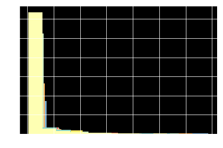

```python
for col in cols[:12]:
    df_pivot[df_pivot[col] >= 1][col].hist()
```

```python
df_pivot_sum_loc = df_pivot.groupby(['id']).sum().reset_index()
```

**Target matrix input format:**

```python
df_pivot_sum_loc.head(5)[['id'] + colswe]
```

| wday_hr | id | we00_01 | we01_02 | we02_03 | we03_04 | we04_05 | we05_06 | we06_07 | we07_08 | we08_09 | ... | we14_15 | we15_16 | we16_17 | we17_18 | we18_19 | we19_20 | we20_21 | we21_22 | we22_23 | we23_24 |
| --- | --- | --- | --- | --- | --- | --- | --- | --- | --- | --- | --- | --- | --- | --- | --- | --- | --- | --- | --- | --- | --- |
| 0 | 183594 | 62.0 | 39.0 | 35.0 | 46.0 | 29.0 | 37.0 | 44.0 | 56.0 | 146.0 | ... | 69.0 | 82.0 | 103.0 | 110.0 | 94.0 | 95.0 | 64.0 | 36.0 | 34.0 | 52.0 |
| 1 | 232280 | 469.0 | 434.0 | 309.0 | 288.0 | 276.0 | 263.0 | 291.0 | 368.0 | 382.0 | ... | 475.0 | 392.0 | 418.0 | 465.0 | 525.0 | 451.0 | 449.0 | 353.0 | 318.0 | 362.0 |
| 2 | 1053153 | 144.0 | 133.0 | 105.0 | 92.0 | 87.0 | 86.0 | 120.0 | 199.0 | 212.0 | ... | 285.0 | 192.0 | 226.0 | 324.0 | 265.0 | 201.0 | 242.0 | 249.0 | 155.0 | 161.0 |
| 3 | 1077642 | 15.0 | 19.0 | 15.0 | 13.0 | 14.0 | 18.0 | 13.0 | 17.0 | 22.0 | ... | 28.0 | 28.0 | 27.0 | 22.0 | 36.0 | 47.0 | 37.0 | 39.0 | 31.0 | 16.0 |
| 4 | 1237965 | 29.0 | 28.0 | 19.0 | 22.0 | 17.0 | 22.0 | 38.0 | 73.0 | 52.0 | ... | 79.0 | 82.0 | 51.0 | 147.0 | 116.0 | 63.0 | 143.0 | 88.0 | 132.0 | 143.0 |

5 rows × 25 columns

```python
df_pivot_merge_sum = pd.merge(df_pivot.drop('IDLocCumSum',axis=1), df_pivot_sum_loc.drop('IDLocCumSum',axis=1), on='id', how='left')
```

```python
orig_cols = [col for col in df_pivot_merge_sum.columns if '_x' in col]
df_pivot.shape, df_pivot_sum_loc.shape, df_pivot_merge_sum.shape
```

```
((35896, 51), (100, 50), (35896, 98))
```

```python
# Normalization of HPs
for col in orig_cols:
    df_pivot_merge_sum[col[:len(col)-2]] = df_pivot_merge_sum[col].map(float) / df_pivot_merge_sum[col[:len(col)-2] + '_y']

interested_cols = [col for col in df_pivot_merge_sum.columns if ('_x' not in col) & ('_y' not in col)]
df_pivot_merge_sum = df_pivot_merge_sum[interested_cols].fillna(0.0)
df_pivot_merge_sum['IDloc'] = df_pivot_merge_sum['id'].map(str) + '_' + df_pivot_merge_sum.latlong
df_pivot_merge_sum.drop(['id','latlong'],axis=1, inplace=True)
```

**Normalized features:**

```python
df_pivot_merge_sum.describe()
```

| wday_hr | wd00_01 | wd01_02 | wd02_03 | wd03_04 | wd04_05 | wd05_06 | wd06_07 | wd07_08 | wd08_09 | wd09_10 | ... | we14_15 | we15_16 | we16_17 | we17_18 | we18_19 | we19_20 | we20_21 | we21_22 | we22_23 | we23_24 |
| --- | --- | --- | --- | --- | --- | --- | --- | --- | --- | --- | --- | --- | --- | --- | --- | --- | --- | --- | --- | --- | --- |
| count | 35896.000000 | 35896.000000 | 35896.000000 | 35896.000000 | 35896.000000 | 35896.000000 | 35896.000000 | 35896.000000 | 35896.000000 | 35896.000000 | ... | 35896.000000 | 35896.000000 | 35896.000000 | 35896.000000 | 35896.000000 | 35896.000000 | 35896.000000 | 35896.000000 | 35896.000000 | 35896.000000 |
| mean | 0.002619 | 0.002563 | 0.002619 | 0.002563 | 0.002563 | 0.002619 | 0.002591 | 0.002563 | 0.002507 | 0.002535 | ... | 0.002786 | 0.002786 | 0.002786 | 0.002758 | 0.002758 | 0.002758 | 0.002758 | 0.002758 | 0.002758 | 0.002758 |
| std | 0.041503 | 0.042326 | 0.044241 | 0.043539 | 0.045094 | 0.043112 | 0.041394 | 0.041064 | 0.037067 | 0.038033 | ... | 0.023825 | 0.023199 | 0.023610 | 0.021588 | 0.022387 | 0.022829 | 0.024247 | 0.027578 | 0.028234 | 0.028683 |
| min | 0.000000 | 0.000000 | 0.000000 | 0.000000 | 0.000000 | 0.000000 | 0.000000 | 0.000000 | 0.000000 | 0.000000 | ... | 0.000000 | 0.000000 | 0.000000 | 0.000000 | 0.000000 | 0.000000 | 0.000000 | 0.000000 | 0.000000 | 0.000000 |
| 25% | 0.000000 | 0.000000 | 0.000000 | 0.000000 | 0.000000 | 0.000000 | 0.000000 | 0.000000 | 0.000000 | 0.000000 | ... | 0.000000 | 0.000000 | 0.000000 | 0.000000 | 0.000000 | 0.000000 | 0.000000 | 0.000000 | 0.000000 | 0.000000 |
| 50% | 0.000000 | 0.000000 | 0.000000 | 0.000000 | 0.000000 | 0.000000 | 0.000000 | 0.000000 | 0.000000 | 0.000000 | ... | 0.000000 | 0.000000 | 0.000000 | 0.000000 | 0.000000 | 0.000000 | 0.000000 | 0.000000 | 0.000000 | 0.000000 |
| 75% | 0.000000 | 0.000000 | 0.000000 | 0.000000 | 0.000000 | 0.000000 | 0.000000 | 0.000000 | 0.000000 | 0.000000 | ... | 0.000000 | 0.000000 | 0.000000 | 0.000000 | 0.000000 | 0.000000 | 0.000000 | 0.000000 | 0.000000 | 0.000000 |
| max | 1.000000 | 1.000000 | 1.000000 | 1.000000 | 1.000000 | 1.000000 | 1.000000 | 1.000000 | 1.000000 | 1.000000 | ... | 0.861314 | 0.872727 | 0.862348 | 1.000000 | 1.000000 | 1.000000 | 1.000000 | 1.000000 | 1.000000 | 1.000000 |

8 rows × 48 columns

```python
exclude = ['id','latlong']
for col in exclude:
    interested_cols.remove(col)
```

# PCA

- apply PCA to capture the common presence patterns across the population
- each eigenvector is an eigenlocation, which represents a typical presence pattern

  U = {uloc1,uloc2,uloc1}

  Phi(i) = T(i) - lambda => id1loc1 - overall average => column-wise normalization

```python
features = interested_cols
x = df_pivot_merge_sum.loc[:,features].values
features_avg_presence = df_pivot_merge_sum[features].mean()

#preprocess
features_avg_presence = np.array(features_avg_presence).reshape((1,48))
np.shape(features_avg_presence)
x = x-features_avg_presence
```

```python
from sklearn.decomposition import PCA

pca = PCA(n_components=3)

principalComponents = pca.fit_transform(x)

principalDf = pd.DataFrame(data = principalComponents
             , columns = ['prinComp1', 'prinComp2','prinComp3'])
```

**Eigenvalues:**

```python
# eigenvalues
n_samples = x.shape[0]
# We center the data and compute the sample covariance matrix.
x -= np.mean(x, axis=0)
cov_matrix = np.dot(x.T, x) / n_samples
for eigenvector in pca.components_:
    print(np.dot(eigenvector.T, np.dot(cov_matrix, eigenvector)))
```

```
0.01903110545192459
0.005566346346306893
0.004094373973169163
```

```python
# eigenvalues
pca.explained_variance_
```

```
array([0.01903164, 0.0055665 , 0.00409449])
```

**Explained variance of each eigenlocation:**

```python
pca.explained_variance_ratio_
```

```
array([0.35509728, 0.10386125, 0.07639604])
```

```python
import numpy as np
loadings = pca.components_.T * np.sqrt(pca.explained_variance_)
np.shape(loadings)
```

```
(48, 3)
```

**Visualize the top 3 eigenlocations:**

```python
loadings = loadings.reshape((3,48))
```

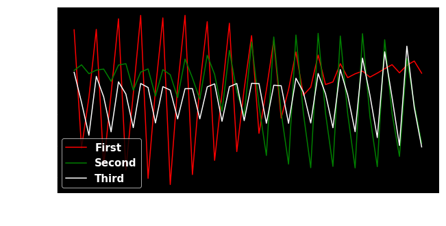

```python
plt.figure(figsize=(10,5))
plt.plot(loadings[0],color='red',label='First')
plt.plot(loadings[1],color='green',label='Second')
plt.plot(loadings[2],color='white',label='Third')
plt.xlabel('Hour')
plt.ylabel('Loadings')
plt.legend()
```

## Cumulative explained variances

```python
#Calculating Eigenvecors and eigenvalues of Covariance matrix
mean_vec = np.mean(x, axis=0)
cov_mat = np.cov(x.T)
eig_vals, eig_vecs = np.linalg.eig(cov_mat)

# Create a list of (eigenvalue, eigenvector) tuples
eig_pairs = [ (np.abs(eig_vals[i]),eig_vecs[:,i]) for i in range(len(eig_vals))]

# Sort from high to low
eig_pairs.sort(key = lambda x: x[0], reverse= True)

# Calculation of Explained Variance from the eigenvalues
tot = sum(eig_vals)
var_exp = [(i/tot)*100 for i in sorted(eig_vals, reverse=True)] # Individual explained variance
cum_var_exp = np.cumsum(var_exp) # Cumulative explained variance
```

```python
cum_var_exp[:3]
```

```
array([35.50972806, 45.89585332, 53.53545717])
```

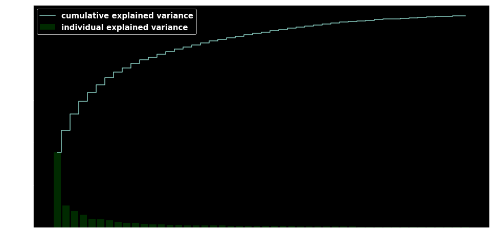

```python
 plt.figure(figsize=(16, 8))
plt.bar(range(len(var_exp)), var_exp, alpha=0.3333, align='center', label='individual explained variance', color = 'g')
plt.step(range(len(cum_var_exp)), cum_var_exp, where='mid',label='cumulative explained variance')
plt.ylabel('Explained variance ratio')
plt.xlabel('Principal components')
plt.legend(loc='best')
plt.show()
```

- In the analysis before this, I just selected top 3 eigenlocations (eigenvectors), but the plot above shows that the second and thrid eigenlocations are not that different from the successive eigenlocations. So, it makes sense to consider using more than 3 eigenvectors.

# K-Means

```python
pca = PCA(n_components=10)
x_10d = pca.fit_transform(x)

pca3 = PCA(n_components=3)
x_3d = pca3.fit_transform(x)
```

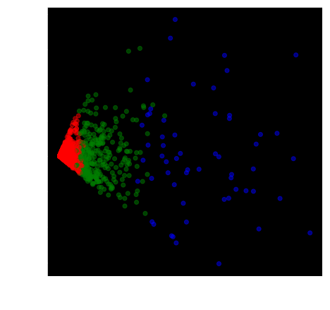

```python
#Set a 3 KMeans clustering
kmeans = KMeans(n_clusters = 3)

#Compute cluster centers and predict cluster indices
X_clustered = kmeans.fit_predict(x_10d)

LABEL_COLOR_MAP = {0:'r', 1: 'g', 2: 'b'}
label_color = [LABEL_COLOR_MAP[l] for l in X_clustered]

# Plot the scatter digram
plt.figure(figsize = (7,7))
plt.scatter(x_10d[:,0],x_10d[:,2], c= label_color, alpha=0.5)
plt.xlabel('Principal Component 1')
plt.ylabel('Principal Component 2')
plt.show()
```

```python
df_pivot_merge_sum['cres1'] = X_clustered
df_pivot_merge_sum[['cres1','IDloc']].groupby(['cres1']).count().reset_index()
```

| wday_hr | cres1 | IDloc |
| --- | --- | --- |
| 0 | 0 | 35499 |
| 1 | 1 | 57 |
| 2 | 2 | 340 |

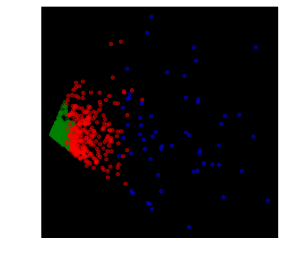

```python
#Set a 3 KMeans clustering
kmeans = KMeans(n_clusters = 3)

#Compute cluster centers and predict cluster indices
X_clustered = kmeans.fit_predict(x_3d)

#Define our own color map
LABEL_COLOR_MAP = {0:'r', 1: 'g', 2: 'b'}
label_color = [LABEL_COLOR_MAP[l] for l in X_clustered]

# Plot the scatter digram
plt.figure(figsize = (7,7))
plt.scatter(x_3d[:,0],x_3d[:,2], c= label_color, alpha=0.5)
plt.xlabel('Principal Component 1')
plt.ylabel('Principal Component 2')
plt.show()
```

```python
df_pivot_merge_sum['cres2'] = X_clustered
df_pivot_merge_sum[['cres2','IDloc']].groupby(['cres2']).count().reset_index()
```

| wday_hr | cres2 | IDloc |
| --- | --- | --- |
| 0 | 0 | 35495 |
| 1 | 1 | 344 |
| 2 | 2 | 57 |

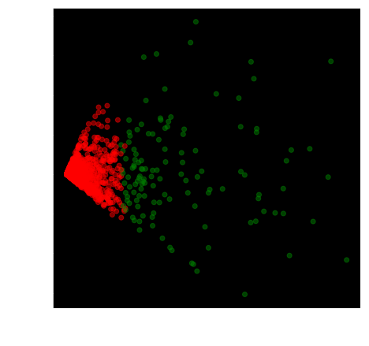

```python
#Set a 3 KMeans clustering
kmeans = KMeans(n_clusters = 2)

#Compute cluster centers and predict cluster indices
X_clustered = kmeans.fit_predict(x_10d)

LABEL_COLOR_MAP = {0:'r', 1: 'g', 2: 'b'}
label_color = [LABEL_COLOR_MAP[l] for l in X_clustered]

# Plot the scatter digram
plt.figure(figsize = (7,7))
plt.scatter(x_10d[:,0],x_10d[:,2], c= label_color, alpha=0.5)
plt.xlabel('Principal Component 1')
plt.ylabel('Principal Component 2')
plt.show()
```

```python
df_pivot_merge_sum['cres3'] = X_clustered
df_pivot_merge_sum[['cres3','IDloc']].groupby(['cres3']).count().reset_index()
```

| wday_hr | cres3 | IDloc |
| --- | --- | --- |
| 0 | 0 | 35769 |
| 1 | 1 | 127 |

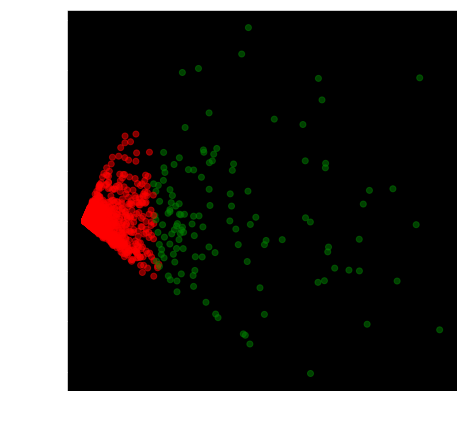

```python
#Set a 3 KMeans clustering
kmeans = KMeans(n_clusters = 2)

#Compute cluster centers and predict cluster indices
X_clustered = kmeans.fit_predict(x_3d)

LABEL_COLOR_MAP = {0:'r', 1: 'g', 2: 'b'}
label_color = [LABEL_COLOR_MAP[l] for l in X_clustered]

# Plot the scatter digram
plt.figure(figsize = (7,7))
plt.scatter(x_3d[:,0],x_3d[:,2], c= label_color, alpha=0.5)
plt.xlabel('Principal Component 1')
plt.ylabel('Principal Component 2')
plt.show()
```

```python
df_pivot_merge_sum['cres4'] = X_clustered
df_pivot_merge_sum[['cres4','IDloc']].groupby(['cres4']).count().reset_index()
```

| wday_hr | cres4 | IDloc |
| --- | --- | --- |
| 0 | 0 | 35768 |
| 1 | 1 | 128 |

```python
df_pivot_merge_sum['cres4'] = X_clustered
df_pivot_merge_sum[['cres4','IDloc']].groupby(['cres4']).count().reset_index()
```

```python
df_pivot_merge_sum['id'] = df_pivot_merge_sum.IDloc.map(lambda x: x.split(sep='_')[0])
df_pivot_merge_sum['lat'] = df_pivot_merge_sum.IDloc.map(lambda x: float(x.split(sep='_')[1].split('-')[0]))
df_pivot_merge_sum['long'] = df_pivot_merge_sum.IDloc.map(lambda x:float(x.split(sep='_')[1].split('-')[1]))
```

```python
df_pivot_merge_sum.tail()
```

| wday_hr | wd00_01 | wd01_02 | wd02_03 | wd03_04 | wd04_05 | wd05_06 | wd06_07 | wd07_08 | wd08_09 | wd09_10 | ... | we22_23 | we23_24 | IDloc | cres1 | cres2 | cres3 | cres4 | id | lat | long |
| --- | --- | --- | --- | --- | --- | --- | --- | --- | --- | --- | --- | --- | --- | --- | --- | --- | --- | --- | --- | --- | --- |
| 35891 | 0.0 | 0.0 | 0.0 | 0.0 | 0.0 | 0.0 | 0.0 | 0.0 | 0.0 | 0.0 | ... | 0.0 | 0.0 | 63866436_25.092-121.461 | 0 | 0 | 0 | 0 | 63866436 | 25.092 | 121.461 |
| 35892 | 0.0 | 0.0 | 0.0 | 0.0 | 0.0 | 0.0 | 0.0 | 0.0 | 0.0 | 0.0 | ... | 0.0 | 0.0 | 63866436_25.092-121.462 | 0 | 0 | 0 | 0 | 63866436 | 25.092 | 121.462 |
| 35893 | 0.0 | 0.0 | 0.0 | 0.0 | 0.0 | 0.0 | 0.0 | 0.0 | 0.0 | 0.0 | ... | 0.0 | 0.0 | 63866436_25.092-121.463 | 0 | 0 | 0 | 0 | 63866436 | 25.092 | 121.463 |
| 35894 | 0.0 | 0.0 | 0.0 | 0.0 | 0.0 | 0.0 | 0.0 | 0.0 | 0.0 | 0.0 | ... | 0.0 | 0.0 | 63866436_25.093000000000004-121.471 | 0 | 0 | 0 | 0 | 63866436 | 25.093 | 121.471 |
| 35895 | 0.0 | 0.0 | 0.0 | 0.0 | 0.0 | 0.0 | 0.0 | 0.0 | 0.0 | 0.0 | ... | 0.0 | 0.0 | 63866436_25.095-121.464 | 0 | 0 | 0 | 0 | 63866436 | 25.095 | 121.464 |

5 rows × 56 columns

## Clustering 1

```python
df_pivot_merge_sum[['cres1','IDloc']].groupby(['cres1']).count().reset_index()
```

| wday_hr | cres1 | IDloc |
| --- | --- | --- |
| 0 | 0 | 35499 |
| 1 | 1 | 57 |
| 2 | 2 | 340 |

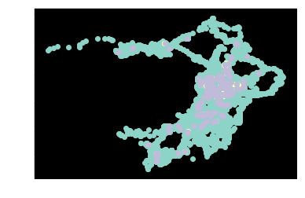

```python
plt.scatter(df_pivot_merge_sum[df_pivot_merge_sum.cres1==0]['lat'],df_pivot_merge_sum[df_pivot_merge_sum.cres1==0]['long'])
plt.scatter(df_pivot_merge_sum[df_pivot_merge_sum.cres1==1]['lat'],df_pivot_merge_sum[df_pivot_merge_sum.cres1==1]['long'])
plt.scatter(df_pivot_merge_sum[df_pivot_merge_sum.cres1==2]['lat'],df_pivot_merge_sum[df_pivot_merge_sum.cres1==2]['long'])
```

```python
sid = list(set(df_pivot_merge_sum[df_pivot_merge_sum.cres1==1].id))
```

```
14997015
```

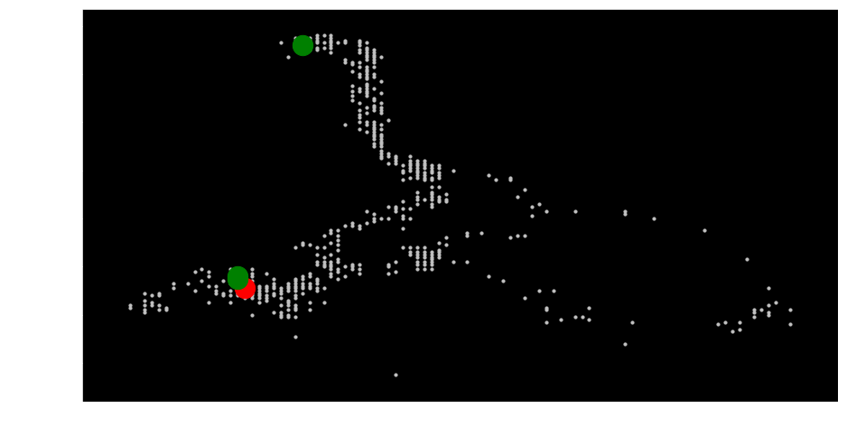

```python
s_id = sid[16]
print(s_id)

LABEL_COLOR_MAP = {0:['silver',10], 1: ['r',500], 2: ['g',500]}

plt.figure(figsize=(15,8))
for i in range(0,len(set(df_pivot_merge_sum.cres1))):
    plt.scatter(df_pivot_merge_sum[(df_pivot_merge_sum.cres1==i) & (df_pivot_merge_sum.id==s_id)]['lat'],df_pivot_merge_sum[(df_pivot_merge_sum.cres1==i) & (df_pivot_merge_sum.id==s_id)]['long'],color=LABEL_COLOR_MAP[i][0],s=LABEL_COLOR_MAP[i][1])

plt.xlabel('Latitude')
plt.ylabel('Longitude')
```

## Clustering 2

```python
df_pivot_merge_sum[['cres2','IDloc']].groupby(['cres2']).count().reset_index()
```

| wday_hr | cres2 | IDloc |
| --- | --- | --- |
| 0 | 0 | 35495 |
| 1 | 1 | 344 |
| 2 | 2 | 57 |

```python
cluster_0 = df_pivot_merge_sum[df_pivot_merge_sum.cres2==0][interested_cols]
cluster_1 = df_pivot_merge_sum[df_pivot_merge_sum.cres2==1][interested_cols]
cluster_2 = df_pivot_merge_sum[df_pivot_merge_sum.cres2==2][interested_cols]
```

```python
min(list(cluster_0.mean())),max(list(cluster_0.mean()))
```

```
(0.0005630761450268034, 0.0017016400466908254)
```

```python
import matplotlib
font = {'family' : 'normal',
        'weight' : 'bold',
        'size'   : 15}

matplotlib.rc('font', **font)
```

[figure not shown]

```python
#Home hours: home hours (before 8 am and after 7 pm) as most other research
plt.figure(figsize=(10,6))
plt.plot(list(cluster_0.mean()), color='gray')
plt.plot(list(cluster_1.mean()), color='green',label='Work')
plt.plot(list(cluster_2.mean()), color='red', label='Home') #===> Home
plt.axvline(x=7,linestyle='--')
plt.axvline(x=18,linestyle='--')
#plt.axvline(x=24,linestyle='-')
plt.axvline(x=31,linestyle='--')
plt.axvline(x=40,linestyle='--')
plt.xlabel('Hour')
plt.ylabel('Normalize Hourly Presences')
plt.legend()
```

```
62635378
```

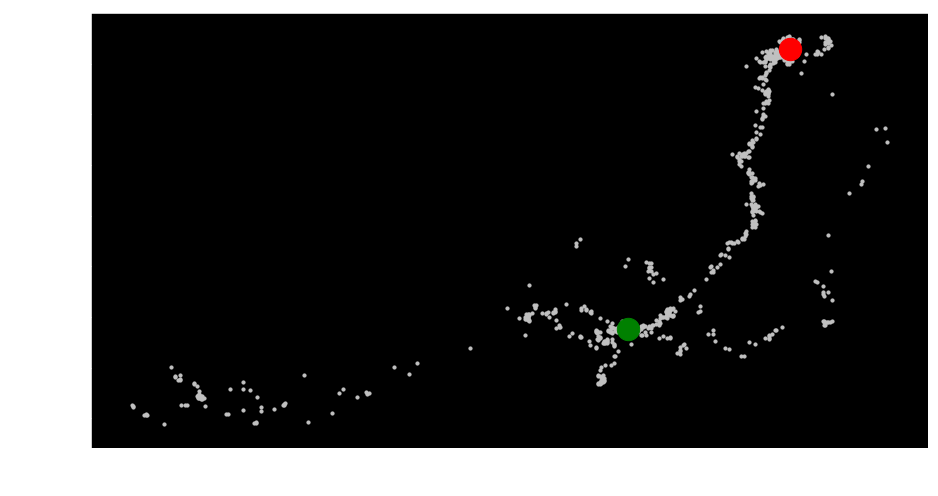

```python
s_id = sid[5]
print(s_id)
LABEL_COLOR_MAP = {0:['silver',10], 1: ['g',500], 2: ['r',500]}
plt.figure(figsize=(15,8))
for i in range(0,len(set(df_pivot_merge_sum.cres1))):
    plt.scatter(df_pivot_merge_sum[(df_pivot_merge_sum.cres2==i) & (df_pivot_merge_sum.id==s_id)]['lat'],df_pivot_merge_sum[(df_pivot_merge_sum.cres2==i) & (df_pivot_merge_sum.id==s_id)]['long'],color=LABEL_COLOR_MAP[i][0],s=LABEL_COLOR_MAP[i][1])

plt.xlabel('Latitude')
plt.ylabel('Longitude')
```

## Clustering 3

```python
cluster_0 = df_pivot_merge_sum[df_pivot_merge_sum.cres3==0][interested_cols]
cluster_1 = df_pivot_merge_sum[df_pivot_merge_sum.cres3==1][interested_cols]
```

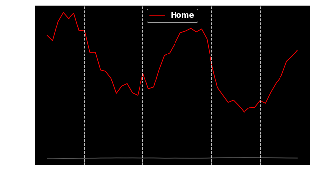

```python
#Home hours: home hours (before 8 am and after 7 pm) as most other research
plt.figure(figsize=(10,6))
plt.plot(list(cluster_0.mean()), color='gray')
plt.plot(list(cluster_1.mean()), color='red', label='Home') #===> Home
plt.axvline(x=7,linestyle='--')
plt.axvline(x=18,linestyle='--')
#plt.axvline(x=24,linestyle='-')
plt.axvline(x=31,linestyle='--')
plt.axvline(x=40,linestyle='--')
plt.xlabel('Hour')
plt.ylabel('Normalize Hourly Presences')
plt.legend()
```

```python
df_pivot_merge_sum[['cres3','IDloc']].groupby(['cres3']).count().reset_index()
```

| wday_hr | cres3 | IDloc |
| --- | --- | --- |
| 0 | 0 | 35769 |
| 1 | 1 | 127 |

```
1237965
```

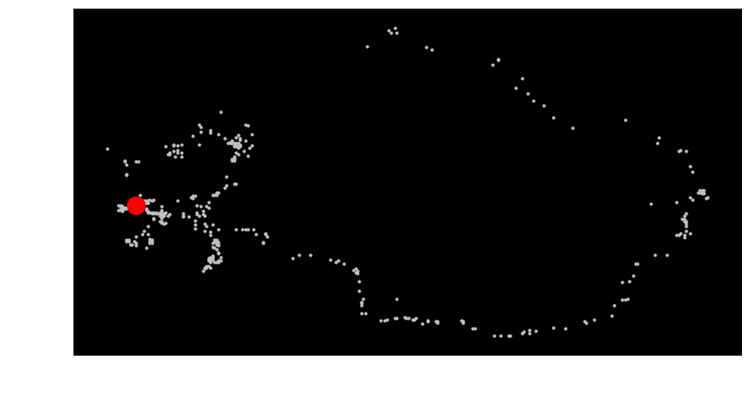

```python
s_id = sid[1]
print(s_id)
LABEL_COLOR_MAP = {0:['silver',10], 1: ['r',500]}

plt.figure(figsize=(15,8))
for i in range(0,len(set(df_pivot_merge_sum.cres3))):
    plt.scatter(df_pivot_merge_sum[(df_pivot_merge_sum.cres3==i) & (df_pivot_merge_sum.id==s_id)]['lat'],df_pivot_merge_sum[(df_pivot_merge_sum.cres3==i) & (df_pivot_merge_sum.id==s_id)]['long'],color=LABEL_COLOR_MAP[i][0],s=LABEL_COLOR_MAP[i][1])

plt.xlabel('Latitude')
plt.ylabel('Longitude')
```